# Lesson 5 Solution

Daniel Baller

1/20/2021

## Review

Key concepts

- five tidyverse verbs
- relational data bases
- split, apply, combine

Review Question

- Using the Batting data frame, determine who held the *career* home run record by season from 1900 to the present. In other words, produce a table with one row per season indicating who the current career home run leader was in baseball at that time. Add their full name to the table using the People data frame.

Here is one approach:

- Add a column to the Batting data frame indicating each player’s cumulative home runs (hint: cumsum) at the end of the season.
- write a function that takes a data frame and a year as arguments and returns the player with the most career homeruns that year or earlier.
- map the function over the seasons from 1900 to 2019.
- add player information from the People data frame

```r
# add career homeruns to Batting
homeruns = Batting %>%
  select(yearID, playerID, HR) %>%
  group_by(playerID) %>%
  mutate(HRcareer = cumsum(HR))

#function to calculate career leader as of year = year
careerLeader = function(data, year){
  data %>%
    filter(yearID <= year) %>%
    arrange(-HRcareer) %>%
    select(playerID, HRcareer, yearID) %>%
    head(1)
}

# map function over each year

leaders = 1900:2019 %>% map_dfr(data = homeruns, careerLeader)

# another way to apply the function
# leaders = 1900:2019 %>%
#    map_df(function(x) careerLeader(data = homeruns, year = x))

# add year information
leaders = leaders %>% ungroup() %>% mutate(year = seq(from = 1900, to = 2019, by = 1))

# another way to add the years
# leaders = data.frame(year = 1900:2019, leaders)

#add player's full name
leaders = leaders %>%
  left_join(select(People, playerID, nameFirst, nameLast))

leaders %>%
  kable(caption = "Career home run leader by season. yearID indicates the season the record was set")
```

Career home run leader by season. yearID indicates the season the record was set

| playerID | HRcareer | yearID | year | nameFirst | nameLast |
| --- | --- | --- | --- | --- | --- |
| connoro01 | 138 | 1897 | 1900 | Roger | Connor |
| connoro01 | 138 | 1897 | 1901 | Roger | Connor |
| connoro01 | 138 | 1897 | 1902 | Roger | Connor |
| connoro01 | 138 | 1897 | 1903 | Roger | Connor |
| connoro01 | 138 | 1897 | 1904 | Roger | Connor |
| connoro01 | 138 | 1897 | 1905 | Roger | Connor |
| connoro01 | 138 | 1897 | 1906 | Roger | Connor |
| connoro01 | 138 | 1897 | 1907 | Roger | Connor |
| connoro01 | 138 | 1897 | 1908 | Roger | Connor |
| connoro01 | 138 | 1897 | 1909 | Roger | Connor |
| connoro01 | 138 | 1897 | 1910 | Roger | Connor |
| connoro01 | 138 | 1897 | 1911 | Roger | Connor |
| connoro01 | 138 | 1897 | 1912 | Roger | Connor |
| connoro01 | 138 | 1897 | 1913 | Roger | Connor |
| connoro01 | 138 | 1897 | 1914 | Roger | Connor |
| connoro01 | 138 | 1897 | 1915 | Roger | Connor |
| connoro01 | 138 | 1897 | 1916 | Roger | Connor |
| connoro01 | 138 | 1897 | 1917 | Roger | Connor |
| connoro01 | 138 | 1897 | 1918 | Roger | Connor |
| connoro01 | 138 | 1897 | 1919 | Roger | Connor |
| connoro01 | 138 | 1897 | 1920 | Roger | Connor |
| ruthba01 | 162 | 1921 | 1921 | Babe | Ruth |
| ruthba01 | 197 | 1922 | 1922 | Babe | Ruth |
| ruthba01 | 238 | 1923 | 1923 | Babe | Ruth |
| ruthba01 | 284 | 1924 | 1924 | Babe | Ruth |
| ruthba01 | 309 | 1925 | 1925 | Babe | Ruth |
| ruthba01 | 356 | 1926 | 1926 | Babe | Ruth |
| ruthba01 | 416 | 1927 | 1927 | Babe | Ruth |
| ruthba01 | 470 | 1928 | 1928 | Babe | Ruth |
| ruthba01 | 516 | 1929 | 1929 | Babe | Ruth |

[output cut: 90 more lines]

## GGplot: its like baking a cake, you create it in layers

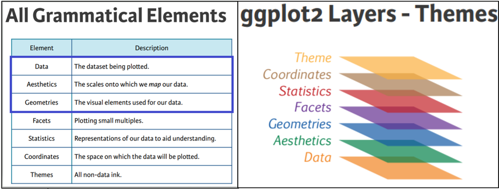

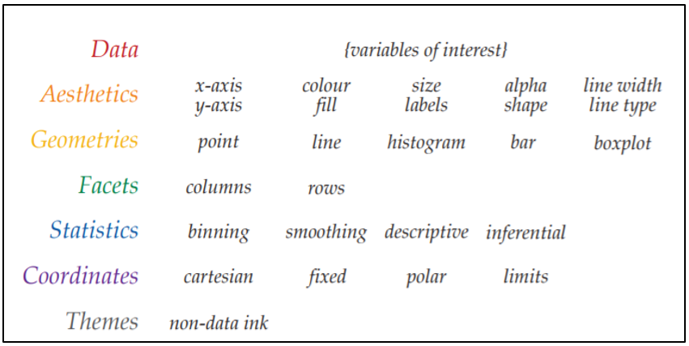

### long vs wide format

With ggplot, you will typically want data in long format as opposed to wide format. What’s the difference?

```r
# here are Mark McGwire and Sammy Sosa's HR for 1998-2001
data_long <- Batting %>%
  filter(yearID >= 1998,
         yearID <= 2001,
         playerID %in% c("mcgwima01","sosasa01")) %>%
  select(yearID, playerID, HR)

#this data is in long format
data_long %>% kable()
```

| yearID | playerID | HR |
| --- | --- | --- |
| 1998 | mcgwima01 | 70 |
| 1998 | sosasa01 | 66 |
| 1999 | mcgwima01 | 65 |
| 1999 | sosasa01 | 63 |
| 2000 | mcgwima01 | 32 |
| 2000 | sosasa01 | 50 |
| 2001 | mcgwima01 | 29 |
| 2001 | sosasa01 | 64 |

```r
data_wide <- data_long %>%
  pivot_wider(id_cols = playerID, names_from = yearID, values_from = HR)

#this data is in wide format
data_wide %>% kable()
```

| playerID | 1998 | 1999 | 2000 | 2001 |
| --- | --- | --- | --- | --- |
| mcgwima01 | 70 | 65 | 32 | 29 |
| sosasa01 | 66 | 63 | 50 | 64 |

```r
#to go back to long format
data_wide %>% pivot_longer(cols = -1, names_to = "Year", values_to = "HR")
```

```
## # A tibble: 8 x 3
##   playerID  Year     HR
##   <chr>     <chr> <int>
## 1 mcgwima01 1998     70
## 2 mcgwima01 1999     65
## 3 mcgwima01 2000     32
## 4 mcgwima01 2001     29
## 5 sosasa01  1998     66
## 6 sosasa01  1999     63
## 7 sosasa01  2000     50
## 8 sosasa01  2001     64
```

A basic ggplot has the data frame, aesthetic, and at least one geometry Going back to the Review, let’s plot the number of home runs for the career home run leader by year.

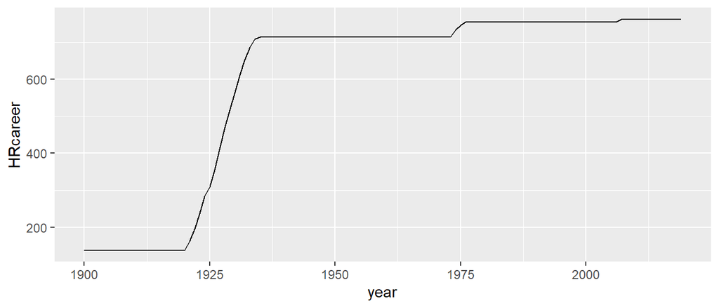

```r
leaders %>%
  ggplot(aes(x =year,
             y = HRcareer)) +
  geom_line()
```

Now, let’s add the player’s name to the plot:

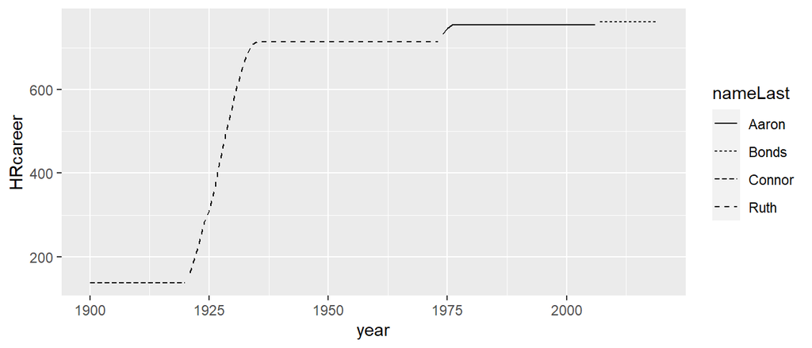

```r
leaders %>%
  ggplot(aes(x = year,
             y = HRcareer,
             linetype = nameLast)) +
  geom_line()
```

We can also do this using color rather than linetype (or both):

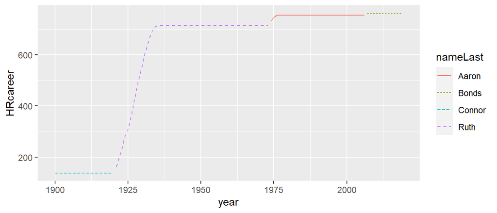

```r
leaders %>%
  ggplot(aes(x = year,
             y = HRcareer,
             linetype = nameLast,
             color = nameLast)) +
  geom_line()
```

Next, let’s change the labels and add a title:

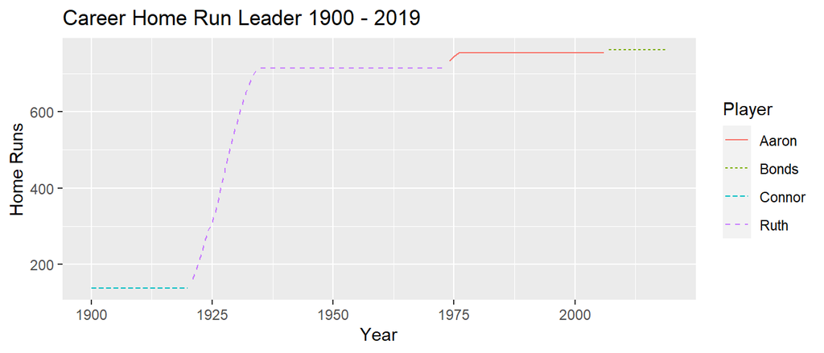

```r
leaders %>%
  ggplot(aes(x = year,
             y = HRcareer,
             linetype = nameLast,
             color = nameLast)) +
  geom_line() +
  labs(x = "Year", y = "Home Runs", color = "Player", linetype = "Player",
       title = "Career Home Run Leader 1900 - 2019")
```

Lastly, let’s change the theme:

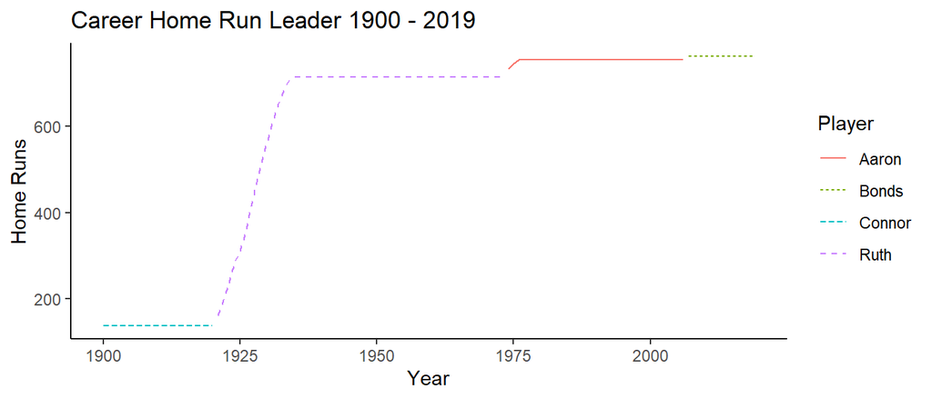

```r
leaders %>%
  ggplot(aes(x = year,
             y = HRcareer,
             linetype = nameLast,
             color = nameLast)) +
  geom_line() +
  labs(x = "Year", y = "Home Runs", color = "Player", linetype = "Player",
       title = "Career Home Run Leader 1900 - 2019")+
  theme_classic()
```

### Your turn

Using the Batting data frame, plot a scatterplot of Henry Aaron’s home runs (`y-axis`) vs batting average (`x-axis`) by season. Color the points in the plot by team name. Change the labels to “Batting Average”, “Home Runs”, and “Team”.

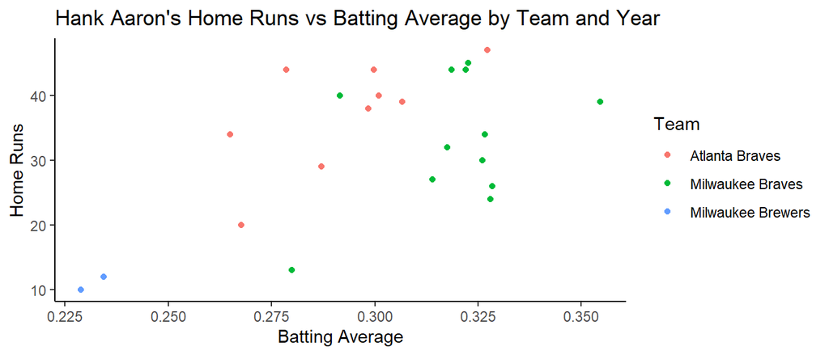

Henry Aaron’s home runs vs batting average by year and team.

```r
aaron = Batting %>%
filter(playerID == "aaronha01") %>% left_join(select(Teams, teamID,
name)) %>% mutate(AVG = H/AB)

aaron %>% ggplot(aes(x = AVG, y = HR, color = name)) + geom_point() +
  labs(x = "Batting Average", y = "Home Runs", color = "Team",
       title = "Hank Aaron's Home Runs vs Batting Average by Team and Year")+
  theme_classic()
```